# PKPDsim tutorial

Ron Keizer

# Introduction

`PKPDsim` is a library for numerical integration of ODE systems, in particular pharmacokinetic-pharmacodynamic (PK-PD) mixed-effects models.

In pharmacometrics, models are often defined as systems of ordinary differential equations (ODEs). Although solving ODEs numerically in R is relatively straightforward using the deSolve library, the implementation of e.g. infusions and complex dosing regimens as well as the incorporation of random effects is cumbersome. A tool like Berkeley Madonna provides excellent interactivity features and is fast[1], but is far inferior to R regarding plotting functionality, cumbersome regarding implementation of dose regimens and multi-level variability, and also not open source/free. This is the rationale for developing the PKPDsim library, i.e. to provide a tool that is:

- easy to use, easy to translate from softwares as NONMEM into R
- flexible and can be used for many different purposes: e.g. teaching, clinical trial simulation, curve fitting, etc.
- fast (through use of compiled code)

# Features

- similar features to Berkeley Madonna but within the R environment, so that the user can take advantage of R’s powerful statistics and visualization tools.
- facilitates simulation of dosing regimens for PKPD mixed-effects models
- for numerical integration, the module uses the fast Boost C++ library. Alternatively, the `deSolve` library can be used too (see examples below), although it will be much slower.
- the PKPDsim library can be used from the R command line, but can also dynamically generate Shiny frontends to allow interactive use for model exploration and teaching purposes.
- the model library in PKPDsim contains a fair selection of PK and PD models, of which a few examples will be shown below. But custom models can easily be implemented too, by specifying the differential equations.

# Installation

```r
library("devtools")
install_github("ronkeizer/PKPDsim")
library("PKPDsim")
```

## Example: model from library

Specifying a dose regimen, selecting a model from the library, simulating the PK, and plotting:

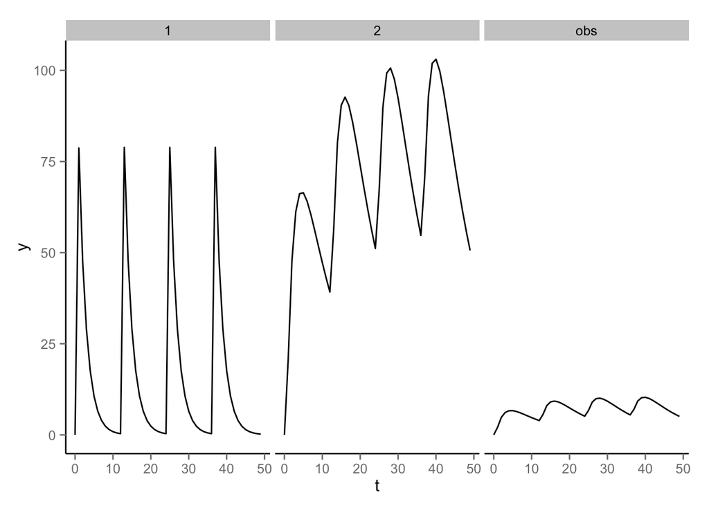

```r
p <- list(CL = 1, V  = 10, KA = 0.5)

pk1 <- new_ode_model("pk_1cmt_oral")

r1 <- new_regimen(amt = 100,
              times = c(0, 12, 24, 36),
              type = "infusion")

dat <- sim_ode (ode = "pk_1cmt_oral",
                par = p,
                regimen = r1)

ggplot(dat, aes(x=t, y=y)) +
  geom_line() +
  facet_wrap(~comp) +
  theme_empty()
```

To simulate between-subject variability, just specify the covariance matrix (`omega`) for the parameters:

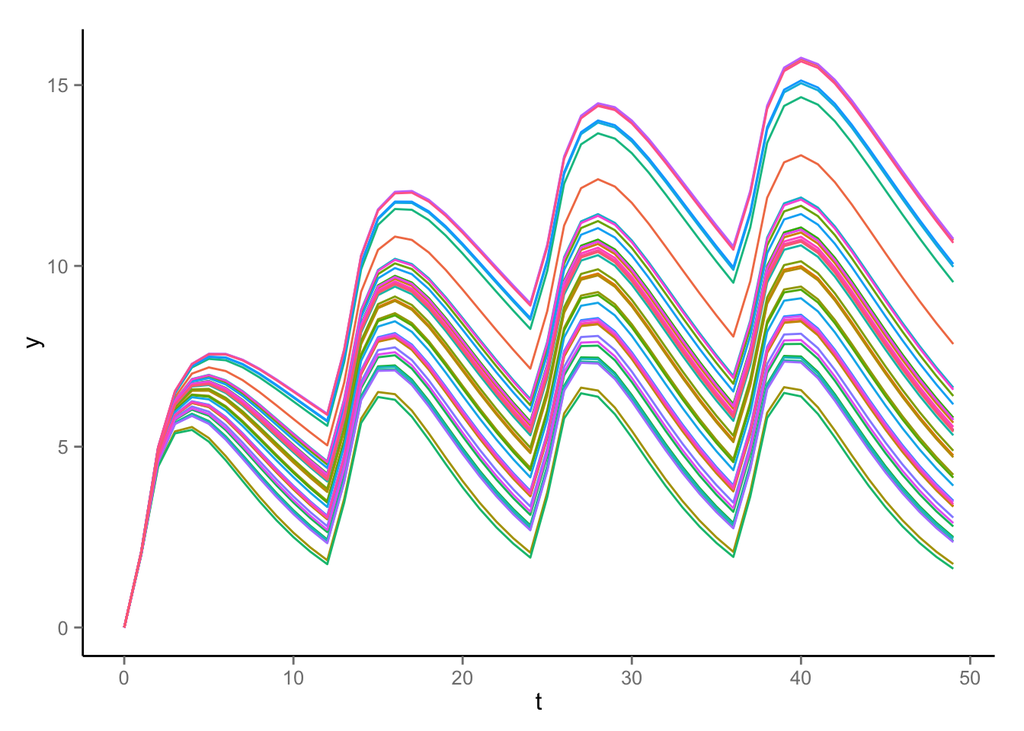

```r
dat2 <- sim_ode (ode = "pk_1cmt_oral",
                par = p,
                n_ind = 40,
                omega = c(0.1,
                          0.05, 0.1),
                regimen = r1)

ggplot(dat2 %>% filter(comp == "obs"), aes(x=t, y=y, group=id, colour=factor(id))) +
  scale_colour_discrete(guide=FALSE) +
  geom_line() +
  theme_empty()
```

Instead of specifying the `omega` matrix, you can also specify between-subject variability as:

```r
omega <- omega_to_cv(list("CL" = 0.1, "V" = 0.1))  # values are standard deviations, assuming exponential distribution
```

## Example: custom model

The model definition should be valid C++ syntax. The code syntax is also highly similar to Berkeley Madonna.

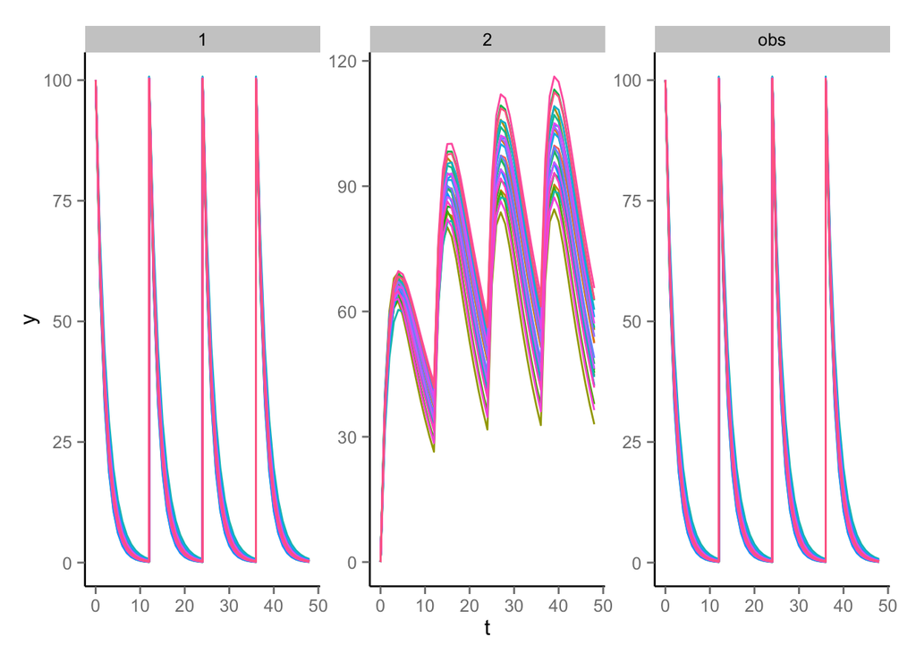

```r
pk2  <- new_ode_model(code = "
                        dAdt[1] = -KA * A[1]
                        dAdt[2] = KA*A[1] -(CL/V) * A[2]
                      ")
r2 <- new_regimen(amt = 100,
              times = c(0, 12, 24, 36),
              type = "oral")

dat <- sim_ode (ode = "pk2",
                n_ind = 25,
                omega = cv_to_omega(par_cv = list("CL"=0.1, "V"=0.1, "KA" = .1), p),
                par = p,
                regimen = r2,
                verbose = FALSE)

ggplot(dat, aes(x=t, y=y, colour=factor(id))) +
  geom_line() +
  scale_colour_discrete(guide=FALSE) +
  facet_wrap(~comp, scales="free") +
  theme_empty()
```

## Example: PK-PD model

Below is an example of a simple indirect-response model. With PK-PD models, the inital state of the PD system often depends on specific model parts. We can define the state of the ODE system statically using the `A_init=` argument, but this will not any (individual) parameters into account. However, we can also define initial states dynamically using the `state_init` argument, so that for each inidividual the desired initial state will be calculated:

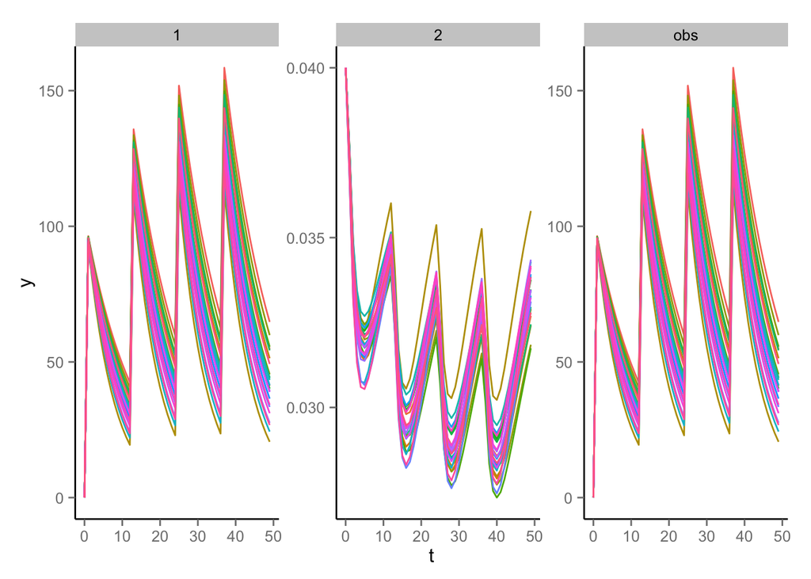

```r
p_pkpd <- list(CL = 5, V  = 50,
               KIN = .02, KOUT=.5, EFF = 0.2)

pkpd <- new_ode_model(
  code = "
    dAdt[1] = -(CL/V) * A[1] + rate
    conc = A[1]/V;
    dAdt[2] = KIN * 1/(1+EFF*conc) - KOUT*A[2];
  ",
  state_init = "A[2] = KIN/KOUT;"
)

dat <- sim_ode (ode = "pkpd",
                n_ind = 25,
                omega = cv_to_omega(par_cv = list("CL"=0.1, "V"=0.1, "KIN" = .05, "KOUT"= 0.1), p),
                par = p_pkpd,
                regimen = r1,
                verbose = FALSE)

ggplot(dat, aes(x=t, y=y, colour=factor(id))) +
  geom_line() +
  scale_colour_discrete(guide=FALSE) +
  facet_wrap(~comp, scales="free") +
  theme_empty()
```

## Example: combine PK and PD models

As shown above, a PK-PD model can be written as a single set of differential equations. However, we often develop PK and PD models separately and e.g. want to plug various PK models into existing PD models. This can be done easily in `PKPDsim` by specifying the model parts in a list to the `code` argument:

```r
pkpd <- new_ode_model(code = list(pk = "
                                    dAdt[1] = -(CL/V) * A[1] + rate;
                                    conc = A[1]/V;
                                  ",
                                  pd = "
                                    dAdt[1] = KIN * 1/(1+EFF*conc) - KOUT*A[1];
                                  "),
                      state_init = list(pd = "A[1] = KIN/KOUT;"))
```

## Example Shiny

The code below will create a Shiny app on-the-fly:

```r
p <- list(CL = 38.48,
          V  = 7.4,
          Q2 = 7.844,
          V2 = 5.19,
          Q3 = 9.324,
          V3 = 111)

omega <- c(0.3,       # IIV CL
           0.1, 0.3)  # IIV V

sim_ode_shiny(ode = "pk_3cmt_iv",
              par = p,
              omega = omega)
```

## Example custom ODE (legacy method, using R::deSolve)

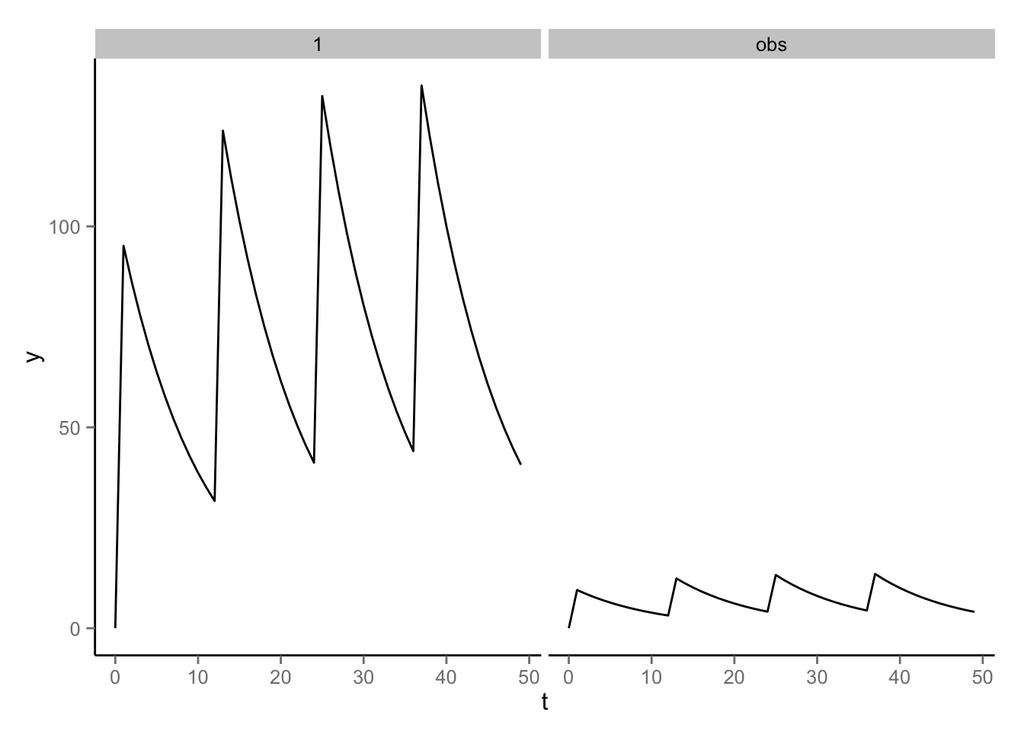

```r
p <- list(CL = 1, V  = 10)

pk_1cmt_iv <- function (t, A, p) {
  with(p, {
    KEL <-  CL/V
    dAdt_1 <- -KEL*A[1] + rate
    return ( list ( c (  dAdt_1 ) ) )
  })
}
attributes(pk_1cmt_iv) <- list(obs = list (cmt = 1, scale = "V"))

dat <- sim_ode (ode = "pk_1cmt_iv",
                par = p,
                regimen = r1)

ggplot(dat, aes(x=t, y=y)) +
  geom_line() +
  facet_wrap(~comp) +
  theme_empty()
```

## Troubleshooting

If you encounter the following message when trying to run a Shiny app:

```
Error in handler(req) :
   argument "metaHandler" is missing, with no default
```

you should update the Shiny library:

```
install.packages("shiny")
```